# STAT395: Sampling

To get a confidence interval proportion for every level of a factor it’s somewhat fiddly with the raw `survey` package:

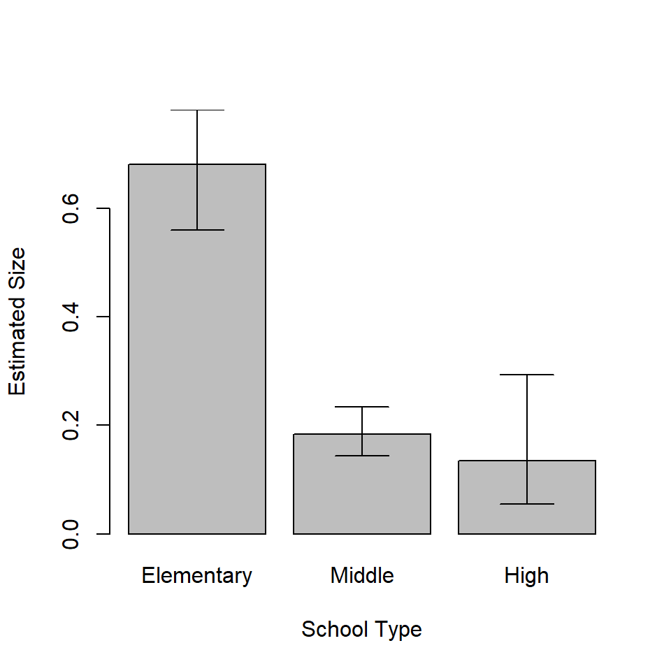

Figure 7.9: Estimated proportions of schools by school type - with asymmetric confidence intervals

```r
ss <- svymean(~stype, design=apiclus2.des)
ci <- t(sapply(levels(apiclus2$stype),
       function(stypelevel) {
          form <- eval(parse(text=paste0("formula(~I(stype==\"",stypelevel,"\"))")))
          confint(svyciprop(form, design=apiclus2.des))
       }))
bp <- barplot(ss, xlab="School Type", ylab="Estimated Size",
              names=levels(apiclus2$stype),
              ylim=c(0,max(ci)))
arrows(bp, ci[,1], bp, ci[,2], angle=90, length=0.2, code=3)
```

```r
names(ss) <- levels(apiclus2$stype)
cbind(as.numeric(ss),ci) |>
  kbl(col.names=c("Estimate","2.5%","97.5%"),
      digits=3,
      caption="Asymmetric confidence interval estimates") |>
  kable_styling(full_width=FALSE)
```

(#tab:tabci.asymmetric)Asymmetric confidence interval estimates

|  | Estimate | 2.5% | 97.5% |
| --- | --- | --- | --- |
| Elementary | 0.681 | 0.560 | 0.782 |
| Middle | 0.185 | 0.144 | 0.234 |
| High | 0.134 | 0.055 | 0.294 |

The biggest thing to notice is that the confidence interval for “High” is now asymmetric: it’s longer on the high side that the low side, and more correctly represents our uncertainty. The estimates for “Elementary” and “Middle” are essentially unchanged.

For **crosstabulations** we can use `svytable()`, which gives weighted counts in categories - e.g. of whether School Wide growth targets had been met

```r
svytable(~stype+sch.wide, design=apiclus2.des)
```

```
##             sch.wide
## stype              No      Yes
##   Elementary  242.240 3251.315
##   Middle      446.630  499.620
##   High        586.675  102.195
```

Which can be displayed with a side-by-side barplot

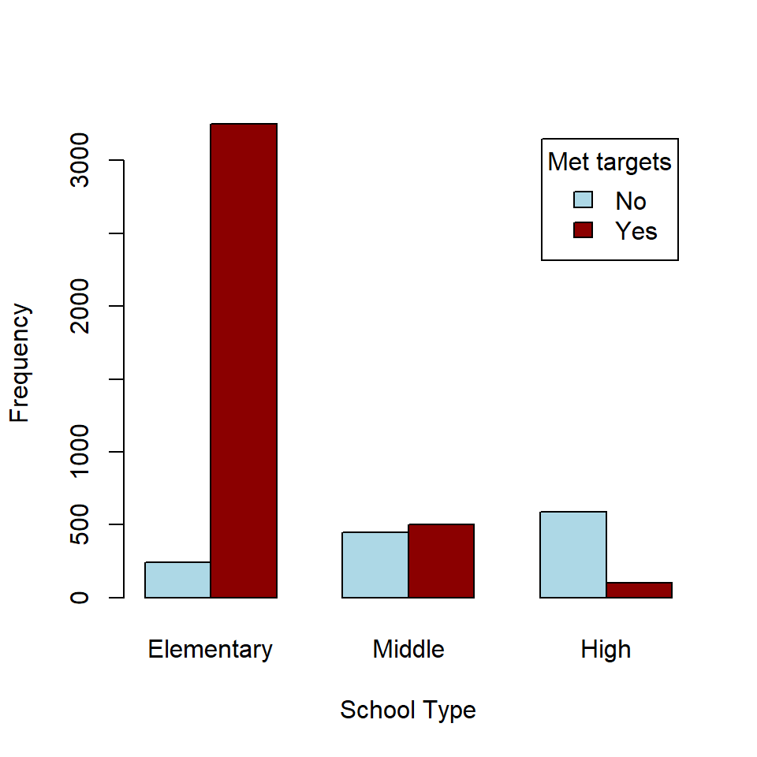

Figure 7.10: Counts of schools meeting targets, by school type

```r
st <- svytable(~sch.wide+stype, design=apiclus2.des)
bp <- barplot(st, beside=TRUE, col=c("light blue","dark red"),
              legend=TRUE, args.legend=list(title="Met targets"),
              xlab="School Type", ylab="Frequency")
```

A test of association is given by the weighted Chi-Square test

```r
svychisq(~stype+sch.wide, design=apiclus2.des)
```

```
##
##  Pearson's X^2: Rao & Scott adjustment
##
## data:  svychisq(~stype + sch.wide, design = apiclus2.des)
## F = 11.873, ndf = 1.3825, ddf = 53.9175, p-value = 0.0003221
```

We can carry out a logistic regression to make a similar test of association.  
We have `sch.wide` as the binary outcome variable and `stype` as the predictor:

```r
summary(svyglm(I(sch.wide=="Yes")~stype, family=quasibinomial(link="logit"),
               design=apiclus2.des))
```

```
##
## Call:
## svyglm(formula = I(sch.wide == "Yes") ~ stype, design = apiclus2.des,
##     family = quasibinomial(link = "logit"))
##
## Survey design:
## svydesign(ids = ~dnum + snum, fpc = ~fpc1 + fpc2, data = apiclus2)
##
## Coefficients:
##             Estimate Std. Error t value Pr(>|t|)
## (Intercept)   2.5969     0.5997   4.331 0.000109 ***
## stypeMiddle  -2.4848     1.1565  -2.148 0.038292 *
## stypeHigh    -4.3445     0.8757  -4.961 1.59e-05 ***
## ---
## Signif. codes:  0 '***' 0.001 '**' 0.01 '*' 0.05 '.' 0.1 ' ' 1
##
## (Dispersion parameter for quasibinomial family taken to be 1.008)
##
## Number of Fisher Scoring iterations: 5
```

With regular `lm()` and `glm()` regression fits we can use F tests to determine whether specific terms in the model should be included. A similar test can be done to test for the inclusion of specific terms using `regTermTest`

```r
sr <- svyglm(I(sch.wide=="Yes")~stype, family=quasibinomial(link="logit"),
               design=apiclus2.des)
regTermTest(sr, ~stype)
```

```
## Wald test for stype
##  in svyglm(formula = I(sch.wide == "Yes") ~ stype, design = apiclus2.des,
##     family = quasibinomial(link = "logit"))
## F =  13.61363  on  2  and  37  df: p= 3.7061e-05
```

Here we can see that `stype` is contributing significantly to the fit of the model.

## 7.3 Ratio estimation

There often arise circumstances in survey analysis where we can expect one variable to be proportional to another: for example population and GDP are likely to move together.

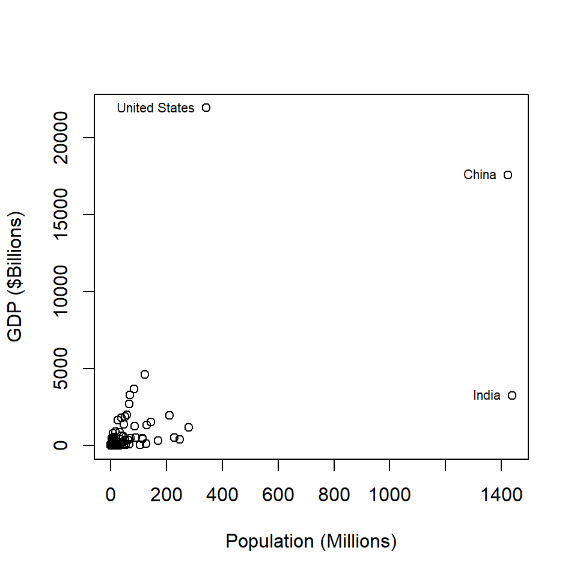

Figure 7.11: Population and GDP (2023) (Source: Our World in Data)

The are three clear outliers here are the US, China and India.

We have full data on $N=150$ countries, and the total GDP of the world in 2023 was $Y=9.1046\times 10^{4}$ in billions of US dollars.

Let’s imagine though that we only had a sample of $n=40$ countries out of the $N=150$ and wanted to estimate the total GDP $Y$. The first 10 rows of our sample are shown below.

| Country | Population | GDP | bigN | weight |
| --- | --- | --- | --- | --- |
| Zambia | 20.723967 | 27.580696 | 150 | 3.75 |
| Saudi Arabia | 33.264289 | 863.963569 | 150 | 3.75 |
| Mauritius | 1.273591 | 14.170188 | 150 | 3.75 |
| Bahrain | 1.569674 | 39.966811 | 150 | 3.75 |
| Benin | 14.111035 | 17.831007 | 150 | 3.75 |
| Myanmar | 54.133800 | 63.756974 | 150 | 3.75 |
| Mozambique | 33.635163 | 20.532020 | 150 | 3.75 |
| Bosnia and Herzegovina | 3.185072 | 20.681711 | 150 | 3.75 |
| Montenegro | 0.633553 | 5.161591 | 150 | 3.75 |
| Japan | 124.370947 | 4601.203386 | 150 | 3.75 |

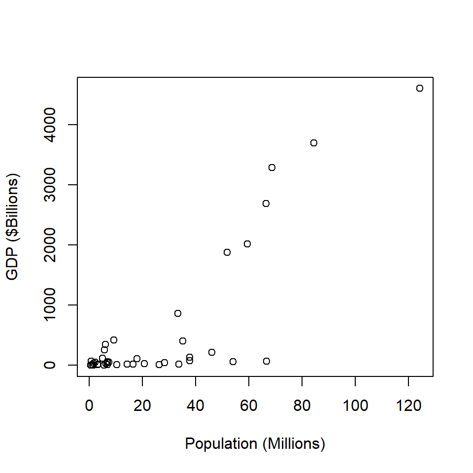

Figure 7.12: Sample of 40 countries: Population and GDP (2023) (Source: Our World in Data)

Our sample happens to miss out on all three of the big countries here. Note that there are some mid-size countries with low GDP visible in the plot, so that the relationship between population and GDP isn’t simple.

Our design specification is:

```r
gdp.sample.des <- svydesign(id=~1, fpc=~bigN, data=gdp.sample)
```

and our total GDP estimate is

```r
ss1 <- svytotal(~GDP, gdp.sample.des)
ss1
```

```
##     total    SE
## GDP 81890 22980
```

This estimate has a very high SE due to the high variability among countries in GDP, and leads to a very wide confidence interval

```r
ci1 <- confint(ss1)
ci1
```

```
##        2.5 %   97.5 %
## GDP 36850.06 126930.8
```

with a very high RSE

```r
cv(ss1)
```

```
##           GDP
## GDP 0.2806213
```

indicating an estimate of low quality.

We could use the correlation between population $x_i$ and GDP $y_i$ and fit a standard regression model
$$y_i = \beta x_i + \varepsilon_i\qquad \varepsilon_i\sim N(0,\sigma^2)$$
omitting the intercept since we want GDP to be proportional to population.

```r
lmfit <- svyglm(GDP ~ -1 + Population, design=gdp.sample.des)
summary(lmfit)
```

```
##
## Call:
## svyglm(formula = GDP ~ -1 + Population, design = gdp.sample.des)
##
## Survey design:
## svydesign(id = ~1, fpc = ~bigN, data = gdp.sample)
##
## Coefficients:
##            Estimate Std. Error t value Pr(>|t|)
## Population   27.870      4.117    6.77 4.44e-08 ***
## ---
## Signif. codes:  0 '***' 0.001 '**' 0.01 '*' 0.05 '.' 0.1 ' ' 1
##
## (Dispersion parameter for gaussian family taken to be 423229.9)
##
## Number of Fisher Scoring iterations: 2
```

The coefficient $\beta$ is the GDP ($Billions) per million people in the population. A 95% confidence interval for $\beta$ is

```r
confint(lmfit)
```

```
##               2.5 %   97.5 %
## Population 19.54262 36.19642
```

It does have a better RSE than our earlier estimate

```r
cv(lmfit)
```

```
## Population
##  0.1477149
```

Scaling the estimated GDP per million by the total population of the world ($X=7646.716928$ million) we still get a rather wide confidence interval

```r
ci2 <- confint(lmfit)*poptotal
ci2
```

```
##               2.5 %   97.5 %
## Population 149436.9 276783.8
```

The reason we’re still not doing very well is that the regression model isn’t a good representation of the situation. Take a look at the residual plot:

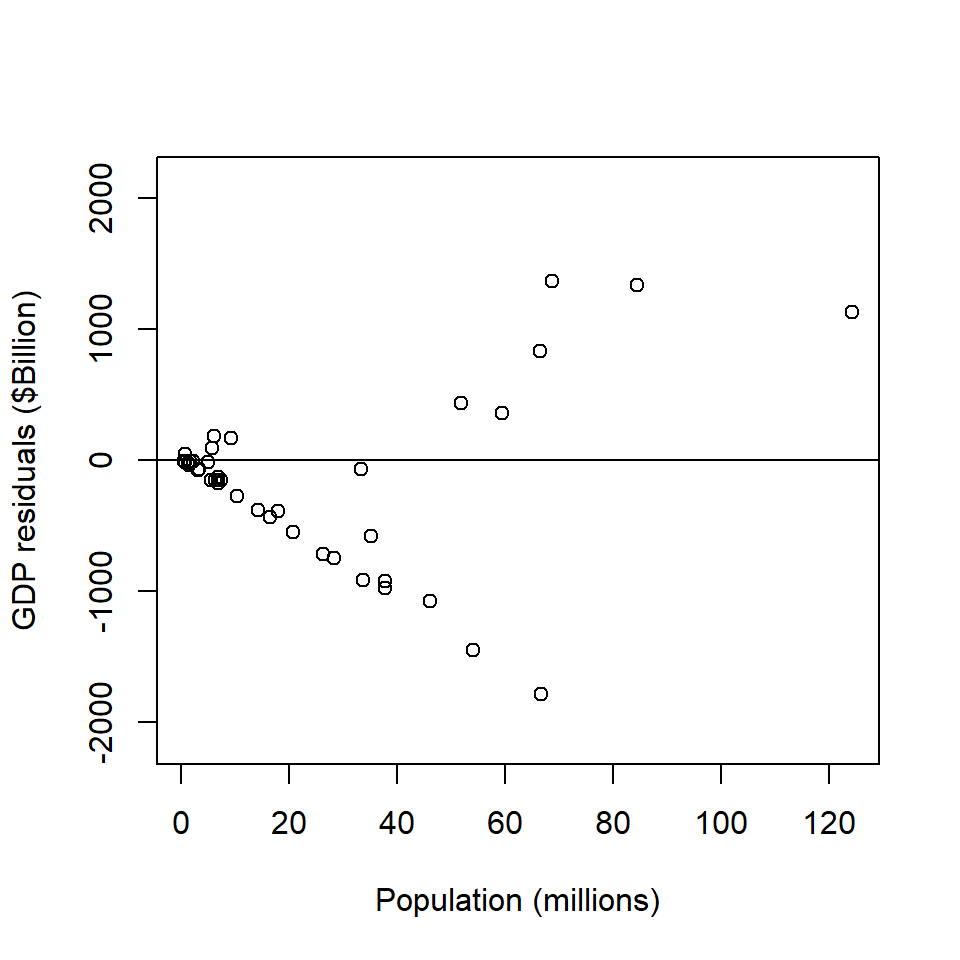

Figure 7.13: Residual plot

This is a terrible looking residual plot, not least because the variance so clearly isn’t constant: there is clear **funnelling** of the residuals. The variance is increasing with population. That isn’t surprising in that there is enormous variety in GDP per capita among the larger countries.

An improvement on the model is to have a residual variance which scales with population $x_i$:
$$y_i = \beta x_i + \varepsilon_i\qquad \varepsilon_i\sim N(0,\sigma^2x_i)$$
We can estimate this ratio of the total of $Y$ to the total of $X$ directly using the `svyratio()` function:

```r
ss3 <- svyratio(~GDP, ~Population, design=gdp.sample.des)
ss3
```

```
## Ratio estimator: svyratio.survey.design2(~GDP, ~Population, design = gdp.sample.des)
## Ratios=
##     Population
## GDP   21.55548
## SEs=
##     Population
## GDP   3.809595
```

```r
confint(ss3)
```

```
##                   2.5 %   97.5 %
## GDP/Population 14.08881 29.02215
```

leading to the following confidence interval for the total GDP of the world in 2023:

```r
ci3 <- confint(ss3)*poptotal
ci3
```

```
##                   2.5 %   97.5 %
## GDP/Population 107733.2 221924.2
```

Collecting all of these results together we see the improvement in our estimate by using the additional information of population size alongside each country’s GDP.

| Method | Estimate | RSE | CI |
| --- | --- | --- | --- |
| Simple | 81890 | 0.28 | (36850,126931) |
| Regression | 213110 | 0.15 | (149437,276784) |
| Ratio | 164829 | 0.18 | (107733,221924) |

## 7.4 Base R Functions and survey package equivalents

| Base R | Survey Package | Notes |
| --- | --- | --- |
| `mean()` | `svymean()` | Mean values (and proportions) |
|  | `svysciprop()` | Confidence intervals for proportions |
| `sd()` | `svysd()` | Standard deviation (needs the `jtools` package) |
| `sum()` | `svytotal()` | Sums |
| `sum()/sum()` | `svyratio()` | Ratios |
| `lm()`, `glm()` | `svyglm()` | Regression |
| `by()` | `svyby()` | Analysis in groups |
| `table()` | `svytable()` | Counts of observations in categories |
| `chisq.test()` | `svychisq()` | Chi-square test of association |
| `hist()` | `svyhist()` | Histogram |
| `boxplot()` | `svyboxplot()` | Boxplot |
| `plot()` | `svyplot()` | Scatter plot |
| `barplot()` | `barplot()` | Bar plot |

# 8 Weight adjustments

## 8.1 Weight Calibration

At the end of a survey we may find ourselves in the undesirable situation that

- **Purely by chance**, the sample is somewhat unbalanced: e.g. by chance we may have selected many more males than females, or more large households than small ones, or
- We may have had **unit nonresponse** - i.e. there may be selected units from which we have collected no data. In the case of human subjects this may have been from a failure to contact the selected person, or the refusal of the person to answer any of our questions. (We may have also had **item nonresponse**, where some items on a questionnaire weren’t answered: we’ll deal with that in the next Chapter.)

In both cases we are in the situation that our sample, even using its sampling weights, is not a good representation of the population from which it is drawn.

For example consider the SURF dataset, which is a synthetic sample of 200 individuals between the ages of 15 and 45. The first 10 rows are shown below.

| Personid | Gender | Qualification | Age | Hours | Income | Marital | Ethnicity | AgeGrp | bigN | weight |
| --- | --- | --- | --- | --- | --- | --- | --- | --- | --- | --- |
| 1 | female | school | 15 | 4 | 87 | never | European | 15-24 | 1972719 | 9863.595 |
| 2 | female | vocational | 40 | 42 | 596 | married | European | 35-45 | 1972719 | 9863.595 |
| 3 | male | none | 38 | 40 | 497 | married | Maori | 35-45 | 1972719 | 9863.595 |
| 4 | female | vocational | 34 | 8 | 299 | never | European | 25-34 | 1972719 | 9863.595 |
| 5 | female | school | 45 | 16 | 301 | married | European | 35-45 | 1972719 | 9863.595 |
| 6 | male | degree | 45 | 50 | 1614 | married | European | 35-45 | 1972719 | 9863.595 |
| 7 | female | none | 36 | 12 | 201 | other | European | 35-45 | 1972719 | 9863.595 |
| 8 | male | degree | 35 | 45 | 934 | previously | European | 35-45 | 1972719 | 9863.595 |
| 9 | female | vocational | 38 | 26 | 624 | married | European | 35-45 | 1972719 | 9863.595 |
| 10 | male | school | 37 | 50 | 533 | previously | European | 35-45 | 1972719 | 9863.595 |

The dataset contains a mixture of numerical and categorical variables, all with very self explanatory names (except note that `Income` and `Hours` are weekly quantities, and also that the income values are somewhat old!). We’ll treat it as a SRSWOR from the New Zealand population between the ages of 15 and 45.

The total population in this age range is $N=1.972719\times 10^{6}$, the sample size is $n=200$, and so the weight of each sampled individual is
$$w = \frac{N}{n} = \frac{1.972719\times 10^{6}}{200} = 9863.6$$
Let’s specify this simple random sampling design to R:

```r
surf.des <- svydesign(id=~1, fpc=~bigN, data=surf)
```

and then estimate the mean income:

```r
svymean(~Income, design=surf.des)
```

```
##          mean     SE
## Income 575.36 24.508
```

We should note that the mean income differs considerably between males and females.

```r
svyby(~Income, by=~Gender, design=surf.des, svymean)
```

```
##        Gender   Income       se
## male     male 732.8172 37.02642
## female female 438.5047 26.16272
```

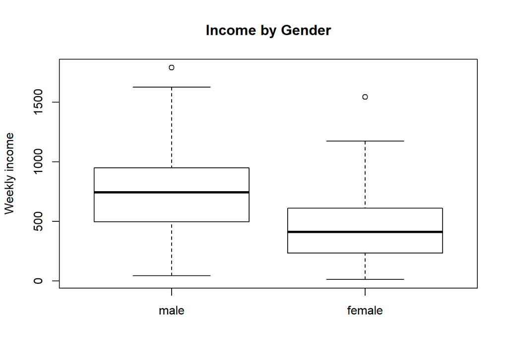

Let’s also note the distribution of the population by age and sex, as measured by the most recent census:

| AgeGrp | male | female | Total |
| --- | --- | --- | --- |
| 15-24 | 324888 | 310032 | 634920 |
| 25-34 | 337845 | 340668 | 678513 |
| 35-45 | 321358 | 337928 | 659286 |
| Total | 984091 | 988628 | 1972719 |

Or we can express these counts as percentages:

| AgeGrp | male | female | Total |
| --- | --- | --- | --- |
| 15-24 | 16.5% | 15.7% | 32.2% |
| 25-34 | 17.1% | 17.3% | 34.4% |
| 35-45 | 16.3% | 17.1% | 33.4% |
| Total | 49.9% | 50.1% | 100.0% |

The proportions of males and females in the population are roughly equal in the population, but in the sample they’re not quite equal:

```r
svymean(~Gender, design=surf.des)
```

```
##               mean     SE
## Gendermale   0.465 0.0354
## Genderfemale 0.535 0.0354
```

This has been caused by our having, by chance, sampled slightly more females than males.

```r
table(surf$Gender)
```

```
##
##   male female
##     93    107
```

The consequence of this is that our estimate of the population mean income is and underestimate, due to females earning less than males, and their being slightly overrepresented in the sample.

One obvious solution to this situation is to slightly upweight the males in the sample, and downweight the females, to take care of the imbalance. Of course we only **know** about the imbalance because we have the census counts which tell us that the proportions of males and females are roughly equal: otherwise we’d have no idea that there might be a problem.

These external counts (external to the survey that is) are called **population benchmarks**, and the weight adjustment that makes the weights match the benchmarks is called **poststratification**. It’s ‘post-’ here because we’re making the stratification (breaking into groups) **after** the survey has taken place. Breaking the sample into groups **beforehand**, and taking separate samples within each group is called stratified sampling. But that is only possible if we know the group membership of sample members before we sample them - i.e. if the group membership information is available on the frame.

We have $n=200$ individuals in a SRSWOR drawn from a population of size $N=1972719$, with weights $w=1972719/200=9863.6$. These correctly add up to the population total
$$n \times w = n \times \frac{N}{n} = 200\times 9863.6 = 1972719$$
What we want is different weights for the males and females, so that they separately add up to the total numbers of males $N_1=984091$ and the total numbers of females $N_2=988628$ in the population. We can achieve this by computing new post-stratified weights using the known benchmarks $N_h$ and sample sizes $n_h$ in each of the post-strata, and computing new weights
$$w_h = \frac{N_h}{n_h}$$
i.e. these are the weights we’d have used if we had actually carried out a stratified sample in the first place.

| Gender | SampWeight | nh | Nh | PostStratWeight |
| --- | --- | --- | --- | --- |
| male | 9863.595 | 93 | 984091 | 10581.624 |
| female | 9863.595 | 107 | 988628 | 9239.514 |

These new weights are now appropriately higher for males and lower for females.

In R we can modify the weights in the design object using the `postStratify()` function. We first need to create a data frame storing the benchmarks:

| Gender | Nh |
| --- | --- |
| male | 984091 |
| female | 988628 |

```r
surf.des.ps <- postStratify(surf.des, strata=~Gender,
                            population=Gender.benchmarks)
```

The orignal estimate of the proportions of males and females

```r
svymean(~Gender, design=surf.des)
```

```
##               mean     SE
## Gendermale   0.465 0.0354
## Genderfemale 0.535 0.0354
```

has been modified to

```r
svymean(~Gender, design=surf.des.ps)
```

```
##                 mean SE
## Gendermale   0.49885  0
## Genderfemale 0.50115  0
```

Notice that the Standard Errors here are zero: these proportions are no longer estimates, they have been **imposed** by our benchmarks.

Then we can compare the orginal estimate of mean income

```r
svymean(~Income, surf.des)
```

```
##          mean     SE
## Income 575.36 24.508
```

with the post-stratified estimate

```r
svymean(~Income, surf.des.ps)
```

```
##          mean     SE
## Income 585.32 22.651
```

The estimate has been increased slightly as expected. Also note that the Standard Error has been reduced: this is often the case with post-stratified estimates: post-stratification makes the properties of different samples differ less than they otherwise would, and thereby reduces our overall uncertainty.

### Poststratification as a treatment for non-response

Non-response can make the small chance differences described in the previous section even worse.

In population surveys males and young people tend to have the lowest response rates. So let’s see what happens to our mean income estimate if we take our sample of 200 individuals and filter out 20% of the male respondents:

```r
set.seed(234)
surf.nonresp <- surf
surf.nonresp$Responds <- rbinom(nrow(surf),1,prob=ifelse(surf$Gender=="male",0.8,1.0))
surf.nonresp <- surf.nonresp[surf.nonresp$Responds==1,]
surf.nonresp$weight <- bigN/nrow(surf.nonresp)
table(surf.nonresp$Gender)
```

```
##
##   male female
##     75    107
```

We’ve now got a lot fewer males than females. Let’s see what this does to the simple estimate of the population mean income:

```r
surf.nonresp.des <- svydesign(id=~1, fpc=~bigN, data=surf.nonresp)
svymean(~Income, design=surf.nonresp.des)
```

```
##          mean     SE
## Income 555.99 24.501
```

The introduction of the non-response has led to a reduction in our original estimate from 575.36 to 555.99.

Post-stratifying however

```r
surf.nonresp.des.ps <- postStratify(surf.nonresp.des, strata=~Gender,
                                    population=Gender.benchmarks)
```

leads to a dramatically improved estimate

```r
svymean(~Income, design=surf.nonresp.des.ps)
```

```
##          mean     SE
## Income 580.73 23.354
```

We know more than just the distribution of the population over Gender, we also know it over the three age groups. So we can post-stratify by these variables too.

We can store the AgeGrp/Gender benchmarks in a data frame `AgeGrp.Gender.benchmarks`:

| AgeGrp | Gender | count |
| --- | --- | --- |
| 15-24 | female | 310032 |
| 15-24 | male | 324888 |
| 25-34 | female | 340668 |
| 25-34 | male | 337845 |
| 35-45 | female | 337928 |
| 35-45 | male | 321358 |

and then post-stratify

```r
surf.nonresp.des.ps2 <- postStratify(surf.nonresp.des, strata=~AgeGrp*Gender,
                                     population=AgeGrp.Gender.benchmarks)
svymean(~Income, design=surf.nonresp.des.ps2)
```

```
##          mean    SE
## Income 580.26 22.66
```

And this is estimate is going to be even better than before.

However where should we stop? Should we post-stratify by as many variables as we possibly can?

In general we need to ensure that we have enough individuals in the sample in every cross-classified cell (in this case AgeGroup by Gender) to be able to recalculate the weight. Empty cells are going to cause us a problem, since we’ll be discarding the population weight associated with people of that type in the population who happen not to have turned up in the sample.

In population surveys run by Statistics NZ we’ll often see post-stratification by age (in 5 year bands), sex, ethnicity (in large amalgamated groups), and large regions.

#### The origin and nature of nonresponse

Post-stratification is often used to modify weights in the presence of non-response. The idea is that in each post-stratum the people who do respond represent well the people who don’t respond.

This is a very big and untestable assumption.

The reasons that people do or don’t respond are complicated. The greatest risk to a survey is that the non-respondents differ from the respondents on the characteristic of interest.

For example if we’re doing a survey of incomes, perhaps all the high income people don’t respond - there’s no way to adjust for this, because the only way to know about income is to have them answer the survey. So we’ll never find out about high income people, nor find out what their incomes actually are.

Post-stratifying the income survey above by age and sex means that we’re assuming that the respondents in each age-sex category are a simple random sample from all of the sample members selected into the survey. We can cope with, and adjust for, differing response rates **between** the post-strata, but we can never adjust for different likelihoods of response **within** the post-strata.

A helpful approach to missing data has a typology with three types of missingness.
If we have auxiliary data ${\bf X}_i$, known for each unit, and are interested in an outcome variable $Y_i$ for each unit, then we are interested in the **probability that unit $i$ will respond if selected**
$$\phi_i = \Pr(\text{Unit $i$ responds} | \text{Unit $i$ is selected})$$

1. **Missing Completely at Random (MCAR)**. This is when the probability of response $\phi_i$ is the same for all units, no matter what their value of $Y_i$ and ${\bf X}_i$.

   This is the best situation: the respondents and nonrespondents do not differ in any important way, and it is as if the nonrespondents had been selected at random from the sample. To analyse data where we have MCAR, we can simply ignore the non-responding units.
2. **Missing at Random (MAR)**. This is also known as ‘missing at random given covariates’ or alternatively ‘ignorable nonresponse.’ This occurs when the probability of response $\phi_i$ depends **only on known quantities**: the auxiliary covariates ${\bf X}_i$, but not on the unknown $Y_i$. We therefore assume that if two units have the same values of ${\bf X}$, then their likelihood of response is the same.

   This is a slightly more complex situation than MCAR, but we can still fully account for nonresponse. This is the approach that post-stratification implements: we treat all respondents as equally likely to respond within the post-strata.
3. **Nonignorable Nonresponse.** This is the unfortunate situation where the probability of response $\phi_i$ depends on the outcome of interest $Y_i$ (as well, possibly, as ${\bf X}_i$).

MAR and MCAR are **strong assumptions**. If the data are MAR we can test whether they are MCAR by comparing nonresponse rates in subgroups defined by ${\bf X}$ (or by logistic regression if any of the X variables are continuous) and test for any dependence on ${\bf X}$.

However it is in general impossible to distinguish whether the data are MAR or whether there is nonignorable response.

We of course exclude from consideration any data which is **missing by design.** There are individuals who if selected turn out to be out of scope (ineligible to participate). These may also be data items which are missing because the respondent is not asked that particular question (e.g. we do not ask for the voting record of children who are not entitled to vote.)

### Raking

We may not have full cross-classified benchmarks, for example we might know the totals by AgeGrp and totals by Gender, but not totals by AgeGrp and Gender simultaneously. In that case we can proceed iteratively: we post-stratify first by one variable, and then by other. Each post-stratification on one variable messes up the post-stratification on the other. But eventually the weights will converge to approximately match both sets of benchmarks. This iteration is called **raking** (like raking a lawn one way, then other other), or **Iterative Proportional Fitting**.

R implements raking in with the `rake()` function. We need a separate set of benchmarks for AgeGrp

|  | AgeGrp | Nh |
| --- | --- | --- |
| 15-24 | 15-24 | 634920 |
| 25-34 | 25-34 | 678513 |
| 35-45 | 35-45 | 659286 |

and for Gender

| Gender | Nh |
| --- | --- |
| male | 984091 |
| female | 988628 |

With these we can rake the design:

```r
surf.nonresp.des.rake <- rake(surf.nonresp.des,
                              sample=list(~AgeGrp, ~Gender),
                              population=list(AgeGrp.benchmarks, Gender.benchmarks))
```

and then calculate our estimates

```r
svymean(~Income, design=surf.nonresp.des.rake)
```

```
##          mean     SE
## Income 579.58 22.798
```

We can compare estimated population totals with the Population benchmarks:

| AgeGrp | male | female | Total |
| --- | --- | --- | --- |
| 15-24 | 324888 | 310032 | 634920 |
| 25-34 | 337845 | 340668 | 678513 |
| 35-45 | 321358 | 337928 | 659286 |
| Total | 984091 | 988628 | 1972719 |

Estimated counts with no weight adjustments

|  | AgeGrp | male | female | SE(male) | SE(female) |
| --- | --- | --- | --- | --- | --- |
| 15-24 | 15-24 | 270977.9 | 357690.8 | 50472.45 | 56491.70 |
| 25-34 | 25-34 | 260138.8 | 346851.7 | 49609.94 | 55815.54 |
| 35-45 | 35-45 | 281817.0 | 455242.8 | 51307.81 | 61776.48 |

Post-stratified by Gender

|  | AgeGrp | male | female | SE(male) | SE(female) |
| --- | --- | --- | --- | --- | --- |
| 15-24 | 15-24 | 328030.3 | 304904.0 | 53712.42 | 44259.49 |
| 25-34 | 25-34 | 314909.1 | 295664.4 | 53150.88 | 43877.23 |
| 35-45 | 35-45 | 341151.5 | 388059.6 | 54225.61 | 46796.67 |

Post-stratified by Age Group cross classified with Gender: exact match to benchmarks

|  | AgeGrp | male | female | SE(male) | SE(female) |
| --- | --- | --- | --- | --- | --- |
| 15-24 | 15-24 | 324888 | 310032 | 0 | 0 |
| 25-34 | 25-34 | 337845 | 340668 | 0 | 0 |
| 35-45 | 35-45 | 321358 | 337928 | 0 | 0 |

Post-stratified by raking to Age Group and Gender marginal totals: approximate match to benchmarks

|  | AgeGrp | male | female | SE(male) | SE(female) |
| --- | --- | --- | --- | --- | --- |
| 15-24 | 15-24 | 327978.3 | 306941.7 | 36276.56 | 36276.56 |
| 25-34 | 25-34 | 348793.8 | 329719.2 | 38089.76 | 38089.76 |
| 35-45 | 35-45 | 307318.9 | 351967.1 | 36046.49 | 36046.49 |

Finally compare the estimates of mean income

| Method | Estimate | SE |
| --- | --- | --- |
| True | 575.3600 | 0.00000 |
| No adjustment | 555.9945 | 24.50130 |
| PS(Gender) | 580.7311 | 23.35388 |
| PS(AgeGrp*Gender) | 580.2640 | 22.65980 |
| Rake(Age+Gender) | 579.5795 | 22.79842 |

The Standard Errors are all similar, though we do get a small reduction in SE with post-stratification. However it is the reduction in the biasing effect of non-response that is most striking.

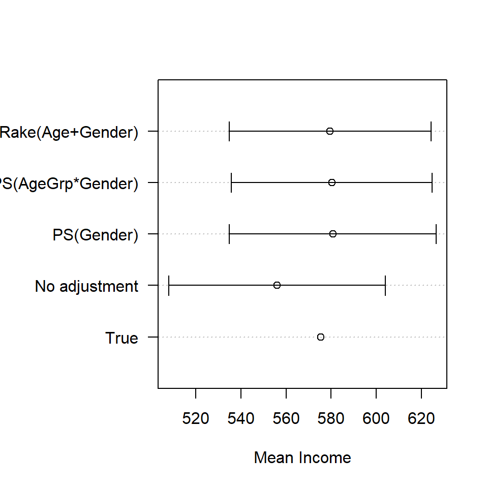

Figure 8.1: Estimates of mean income by adjustment method

### Another example

In the Academic Performance Indicator dataset we have full population information on types of School (`stype`=Elementary/Middle/High) and whether or not they met their year round performance indicators (`yr.rnd`=Yes/No). These counts will be our benchmarks for post-stratification.

The numbers of schools by type are in `stype.benchmarks`

| stype | Freq |
| --- | --- |
| Elementary | 4397 |
| Middle | 1009 |
| High | 751 |

The number of schools by achievement of year round objectives are in `yr.rnd.benchmarks`

| yr.rnd | Freq |
| --- | --- |
| No | 874 |
| Yes | 5283 |

and we also have these counts **cross-classified**, i.e. numbers of schools for each combination of `stype` and `yr.rnd`:

| stype | yr.rnd | Freq |
| --- | --- | --- |
| Elementary | No | 791 |
| Middle | No | 60 |
| High | No | 23 |
| Elementary | Yes | 3606 |
| Middle | Yes | 949 |
| High | Yes | 728 |

Select a two stage cluster sample - and then make estimates of the mean school size (`enroll`)

```r
set.seed(111)
api2sc <- apipopc |>
  select.2sc(n=40, cfraction=0.30, mmin=2, clustervar="dnum")
api2sc.des <- svydesign(ids=~dnum+snum, fpc=~bigN1+bigN2, data=api2sc)
table(api2sc$stype)/nrow(api2sc)
```

```
##
## Elementary     Middle       High
##  0.6224490  0.1428571  0.2346939
```

```r
svytable(~stype, design=api2sc.des)
```

```
## stype
## Elementary     Middle       High
##  2972.2159   589.3841   946.0500
```

```r
svytable(~stype, design=api2sc.des)/sum(api2sc$weight)
```

```
## stype
## Elementary     Middle       High
##  0.6593715  0.1307520  0.2098765
```

```r
svymean(~enroll, design=api2sc.des)
```

```
##          mean     SE
## enroll 711.45 81.057
```

```r
svyby(~enroll, by=~stype, api2sc.des, svymean)
```

```
##                 stype    enroll        se
## Elementary Elementary  415.6678  46.44827
## Middle         Middle  834.1254 113.51448
## High             High 1564.3007 190.86274
```

Poststratify by stype and re-estimate

```r
api2sc.des.ps <- postStratify(api2sc.des, strata=~stype, population=stype.benchmarks)
svymean(~enroll, api2sc.des.ps)
```

```
##          mean     SE
## enroll 624.35 53.142
```

Postratify by stype by yr.rnd and reestimate

```r
api2sc.des.ps2 <- postStratify(api2sc.des, strata=~stype+yr.rnd,
                               population=stype.yr.rnd.benchmarks)
svymean(~enroll, api2sc.des.ps2)
```

```
##          mean     SE
## enroll 629.45 40.239
```

Poststratify by stype + yr.rnd (i.e. we only have the marginals so we need to rake) and reestimate

```r
api2sc.des.rake <- rake(api2sc.des,
                        sample=list(~stype, ~yr.rnd),
                        population=list(stype.benchmarks, yr.rnd.benchmarks))
svymean(~enroll, api2sc.des.rake)
```

```
##          mean     SE
## enroll 632.04 46.705
```

Compare

|  | Estimate | SE |
| --- | --- | --- |
| Cenus | 619.0469 | 0.00000 |
| 2SC | 711.4530 | 81.05714 |
| 2SC+PS(stype) | 624.3485 | 53.14154 |
| 2SC+PS(stype x yr.rnd) | 629.4503 | 40.23927 |
| 2SC+Rake(stype+yr.rnd) | 632.0372 | 46.70502 |

## 8.2 Replicate weights

For some weight adjustments we no longer have a reliable method of computing the standard errors of our estimates. This can occur when we have very complex designs. It can also be necessary when we don’t have access to the frame, and therefore don’t have all the information we need (such as population sizes in clusters) to calculate standard errors.

In such circumstances we often create multiple sets of weights in addition to the adjusted weights. These **replicate weights** are what are used to estimate the standard errors, and they have the advantage that they can create standard errors for a wider range of estimators than the usual means and totals.

The basic idea comes from recalling what standard errors are: they are the variability we’d see in an estimate across all possible samples from the population using the chosen sample design and sample size (Figure 8.2).

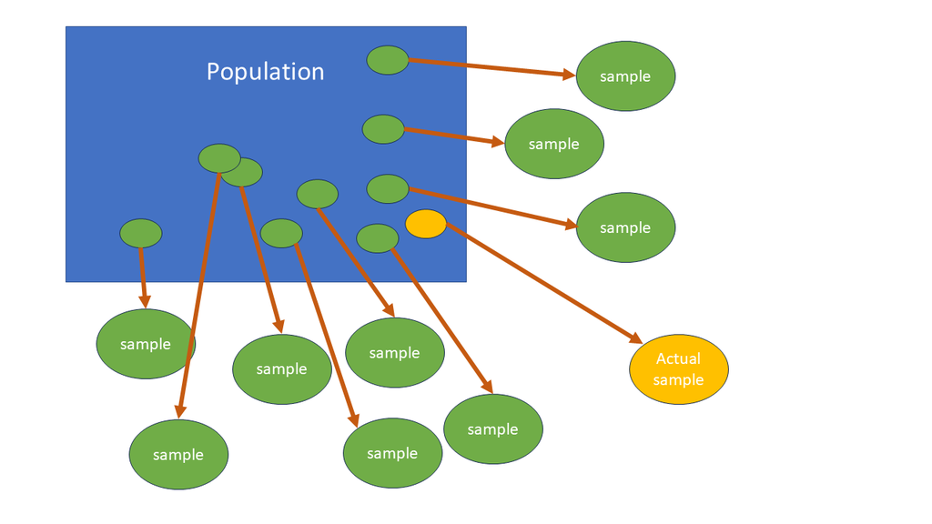

Figure 8.2: Sampling error is the variation among the estimates that would be calculated from all possible samples from the population.

Once we’ve completed a survey we obviously can’t take any more samples from the population. Instead we use the variability we see within the **sample** to capture and estimate the variability we’d see in different samples from the **population** (Figrue 8.3).

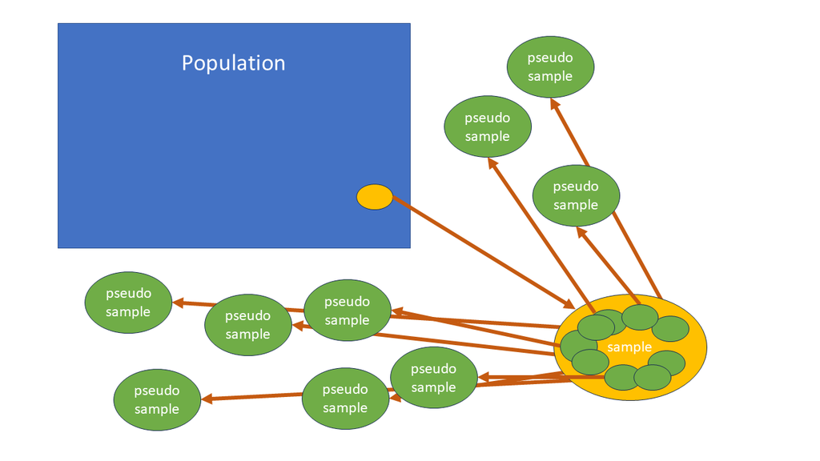

Figure 8.3: In Jacknife estimation sampling error can be estimated by calculating the variability among estimates from subsets taken from the sample. This variability needs to be scaled up to get the true population variability, because the pseudo-samples resemble one another strongly, though not exactly.

Instead of actually resampling from our sample, we instead vary the weights on some or all of the units, and create new sets of weights according to a well defined method. We do this multiple times, which is equivalent to taking multiple re-samples of our actual sample. Each re-sample is called a **replicate** and has its own set of weights for all of the units in the sample. e.g. we might have 100 additional sets of replicate weights attached to our survey data set, as well as the actual weights.

We then use these replicate weights to calculate a set of alternative values for our estimate of interest. The variability among these replicate estimates is then used to determine the standard error.

There are a number of different ways to create replicate weights: we’ll consider just one known as the **Jackknife**.

Each Jacknife replicate set of weights is calculated by deleting one or more PSUs at the first stage of selection by setting their weights to zero. We then rescale the weights of the remaining units so that they still add up to the same total weight (i.e so they weights still add up to the population size). Table 8.1 shows an example.

Table 8.1: Example of Jacknife replicate weights: a sample of 4 clusters (PSUs) with sets of replicate weights, each one deleting the weight of a single PSU, and rescaling to maintain the total of the weights.

| id | psu | weight | rep01 | rep02 | rep03 | rep04 |
| --- | --- | --- | --- | --- | --- | --- |
| 1 | A | 100 | 0.0 | 138.1 | 126.1 | 134.9 |
| 2 | A | 100 | 0.0 | 138.1 | 126.1 | 134.9 |
| 3 | A | 100 | 0.0 | 138.1 | 126.1 | 134.9 |
| 4 | B | 80 | 107.9 | 0.0 | 100.9 | 107.9 |
| 5 | B | 80 | 107.9 | 0.0 | 100.9 | 107.9 |
| 6 | B | 80 | 107.9 | 0.0 | 100.9 | 107.9 |
| 7 | B | 80 | 107.9 | 0.0 | 100.9 | 107.9 |
| 8 | C | 120 | 161.9 | 165.7 | 0.0 | 161.9 |
| 9 | C | 120 | 161.9 | 165.7 | 0.0 | 161.9 |
| 10 | D | 100 | 134.9 | 138.1 | 126.1 | 0.0 |
| 11 | D | 100 | 134.9 | 138.1 | 126.1 | 0.0 |
| 12 | D | 100 | 134.9 | 138.1 | 126.1 | 0.0 |
| Total |  | 1160 | 1160.0 | 1160.0 | 1160.0 | 1160.0 |

We can create a set of replicate weights for the two stage cluster sample from the API data set as follows:

```r
api2sc.jkdes <- as.svrepdesign(api2sc.des, type="JK1")
```

```
## Warning in as.svrepdesign.default(api2sc.des, type = "JK1"): Finite population
## corrections after first stage have been dropped
```

There is an informative warning here: no fpc can apply at second stage of selection (nor any subsequent stages).

The specification **JK1** here indicates that the design is not stratified.

Here are the first 5 rows and 8 columns of replicate weights: each row refers to a PSU (i.e. a district `dnum`) and each column is a replicate.

```r
api2sc.jkdes$repweights$weights[1:5,1:8]
```

```
##          [,1]     [,2]     [,3]     [,4]     [,5]     [,6]     [,7]     [,8]
## [1,] 0.000000 1.025641 1.025641 1.025641 1.025641 1.025641 1.025641 1.025641
## [2,] 1.025641 0.000000 1.025641 1.025641 1.025641 1.025641 1.025641 1.025641
## [3,] 1.025641 1.025641 0.000000 1.025641 1.025641 1.025641 1.025641 1.025641
## [4,] 1.025641 1.025641 1.025641 0.000000 1.025641 1.025641 1.025641 1.025641
## [5,] 1.025641 1.025641 1.025641 1.025641 0.000000 1.025641 1.025641 1.025641
```

Replicate Weights are $n/(n-1)=40/39=1.025641$ - drops one of the 40 selected districts `dnum` out for each replicate, setting the weight for all units selected in that district to zero.

These are called **scaling weights**, and they need to be multiplied by the original sampling weight to get the actual replicate weights.

We can use this design just as in earlier examples to get estimates and standard errors:

```r
svymean(~enroll, design=api2sc.jkdes)
```

```
##          mean     SE
## enroll 711.45 82.848
```

This gives us a good estimate of the SE, similar to what we get from the original sample design specification:

```r
svymean(~enroll, design=api2sc.des)
```

```
##          mean     SE
## enroll 711.45 81.057
```

Note that the estimate itself is identical: in both cases they come from the same single set of sample weights.

If we are needing to post-stratify our weights to account for non-response, then we need also to poststratify each set of replicate weights.

```r
api2sc.jkdes.ps <- postStratify(api2sc.jkdes, strata=~stype, population=stype.benchmarks)
svymean(~enroll, design=api2sc.jkdes.ps)
```

```
##          mean    SE
## enroll 624.35 60.61
```

Here post-stratification gives us a strong reduction of the standard errors, as we saw earlier.

Here’s a comparison of the various estimates and standard errors from the various methods we’ve seen so far:

|  | Estimate | SE |
| --- | --- | --- |
| Cenus | 619.0469 | 0.00000 |
| 2SC | 711.4530 | 81.05714 |
| 2SC+PS(stype) | 624.3485 | 53.14154 |
| 2SC+PS(stype x yr.rnd) | 629.4503 | 40.23927 |
| 2SC+Rake(stype+yr.rnd) | 632.0372 | 46.70502 |
| JK1 | 711.4530 | 82.84780 |
| JK1+PS(stype) | 624.3485 | 60.60973 |

Important points to note:

- the SE is reduced by post-stratification, and
- we get similar SEs when we use the jacknife estimation method.

Let’s take a look at the replicate weights after post-stratification

```r
api2sc.jkdes.ps$repweights$weights[1:5,1:8]
```

```
##      [,1]    [,2]     [,3]     [,4]     [,5] [,6]    [,7]     [,8]
## 1 0.00000 1.00628 1.047964 1.019081 1.000000 1.00 1.00628 1.012640
## 3 0.00000 1.00000 1.000000 1.000000 1.049550 1.00 1.00000 1.067176
## 1 1.00945 0.00000 1.047964 1.019081 1.000000 1.00 1.00628 1.012640
## 1 1.00945 1.00628 0.000000 1.019081 1.000000 1.00 1.00628 1.012640
## 2 1.00000 1.00000 0.000000 1.000000 1.030303 1.02 1.00000 1.000000
```

They’re no longer the same in the different PSUs.

**This seems to be a lot of additional work:** we get the same SEs and estimates using the standard formula-based estimation methods for SEs. Why bother with replicate weights in that case?

There are three reasons:

- For some very **complex designs** there are no formula based estimation methods that can be used;
- For some **estimates**, such as medians and quartiles, replicate methods are more reliable than formula based methods;
- Replicate based methods are robust in the presence of small samples and outliers, and can also be used to estimate bias (as well as standard errors).

It’s commonly the case that rather than calculating them for ourselves we might inestead have been **supplied** replicate weights, i.e. someone else might have created them. This often happens when we have been granted access to a data set collected by a government department or agency concerned about confidentiality, and in those instances we are not given access to the frame.

In which case the weights in the first 10 rows of our API two stage cluster dataset would look like this

| dnum | pweight | repweight001 | repweight002 | repweight003 | repweight004 | repweight005 | repweight006 | repweight007 | repweight008 |
| --- | --- | --- | --- | --- | --- | --- | --- | --- | --- |
| 31 | 41.16340 | 0.00000 | 41.42192 | 43.13775 | 41.94883 | 41.16340 | 41.16340 | 41.42192 | 41.68371 |
| 31 | 47.63519 | 0.00000 | 47.63519 | 47.63519 | 47.63519 | 49.99550 | 47.63519 | 47.63519 | 50.83511 |
| 44 | 27.44227 | 27.70160 | 0.00000 | 28.75850 | 27.96589 | 27.44227 | 27.44227 | 27.61462 | 27.78914 |
| 46 | 100.62165 | 101.57255 | 101.25359 | 0.00000 | 102.54158 | 100.62165 | 100.62165 | 101.25359 | 101.89352 |
| 46 | 53.99346 | 53.99346 | 53.99346 | 0.00000 | 53.99346 | 55.62963 | 55.07333 | 53.99346 | 53.99346 |
| 46 | 100.62165 | 101.57255 | 101.25359 | 0.00000 | 102.54158 | 100.62165 | 100.62165 | 101.25359 | 101.89352 |
| 51 | 41.16340 | 41.55241 | 41.42192 | 43.13775 | 0.00000 | 41.16340 | 41.16340 | 41.42192 | 41.68371 |
| 51 | 41.16340 | 41.55241 | 41.42192 | 43.13775 | 0.00000 | 41.16340 | 41.16340 | 41.42192 | 41.68371 |
| 67 | 47.63519 | 49.99550 | 47.63519 | 47.63519 | 47.63519 | 0.00000 | 47.63519 | 47.63519 | 50.83511 |
| 67 | 22.08824 | 22.08824 | 22.08824 | 23.79930 | 22.08824 | 0.00000 | 22.53000 | 22.08824 | 22.08824 |

Unlike the example earlier, these replicate weights are **combined weights** - i.e. they do not need to be multiplied by the original weight, and they each separately add up to the same value: the population size.

We use a data set like this to specify the sample design to R using just the probability weights `pweight`and the set of replicate weights `repweight001-repweight040`. We don’t specify the cluster variables when specifying the design.

```r
pweightcol <- match("pweight",names(api2sc.withrep.ps)) # which column name is exactly equal to pweight
repweightcols <- grep("^repweight",names(api2sc.withrep.ps)) # which columnnames start with repweight?
varcols <- (1:ncol(api2sc.withrep.ps))
varcols <- varcols[!(varcols%in%c(pweightcol,repweightcols))]
n <- length(unique(api2sc$dnum))
api2sc.repdes.ps <- svrepdesign(variables=api2sc.withrep.ps[,varcols],
                                weights=api2sc.withrep.ps[,pweightcol],
                                repweights=api2sc.withrep.ps[,repweightcols],
                                combined.weights=TRUE,
                                scale=(n-1)/n,
                                type="JK1")
svymean(~enroll, api2sc.repdes.ps)
```

```
##          mean     SE
## enroll 624.35 62.313
```

|  | Estimate | SE |
| --- | --- | --- |
| Cenus | 619.0469 | 0.00000 |
| 2SC | 711.4530 | 81.05714 |
| 2SC+PS(stype) | 624.3485 | 53.14154 |
| 2SC+PS(stype x yr.rnd) | 629.4503 | 40.23927 |
| 2SC+Rake(stype+yr.rnd) | 632.0372 | 46.70502 |
| JK1 | 711.4530 | 82.84780 |
| JK1+PS(stype) | 624.3485 | 60.60973 |
| JK1+PS(stype); weights only | 624.3485 | 62.31259 |

The consequence of only being given the weights (rather than the full clustering information) means that the first stage design is treated as PPSWR rather than SRSWOR, and there is no adjustment for the fpc. That means the SEs are slightly larger.

The method “JK1” is used for unstratified designs. For stratified designs the jackknife is specified by “JKn”: we don’t just drop out one PSU over the whole sample in each replicate, instead we drop out a PSU from every stratum simultaneously.

E.g. draw a two stage cluster sample within two strata: schools which are or are not eligible for an awards programme:

```r
set.seed(999)
apist2sc <- apipopc |>
  select.st2sc(n=40, stratumvar="awards", cfraction=0.20, clustervar="dnum")
apist2sc.des <- svydesign(id=~dnum+snum, strata=~awards, fpc=~bigN1+bigN2,
                          data=apist2sc, nest=TRUE)
apist2sc.des.ps <- postStratify(apist2sc.des, strata=~stype, population=stype.benchmarks)
```

Note: we need `nest=TRUE` here because districts `dnum` do not nest within strata. I.e. it is the **combination** of `awards` and `dnum` that actually defines the clusters here.

```r
svymean(~enroll, design=apist2sc.des)
```

```
##          mean     SE
## enroll 497.75 64.645
```

```r
svymean(~enroll, design=apist2sc.des.ps)
```

```
##          mean     SE
## enroll 523.97 63.001
```

```r
apist2sc.jkdes <- as.svrepdesign(apist2sc.des, type="JKn")
svymean(~enroll, design=apist2sc.jkdes)
```

```
##          mean     SE
## enroll 497.75 84.997
```

```r
apist2sc.jkdes.ps <- postStratify(apist2sc.jkdes, strata=~stype, population=stype.benchmarks)
svymean(~enroll, design=apist2sc.jkdes.ps)
```

```
##          mean     SE
## enroll 523.97 82.125
```

There are alternative methods to Jacknife generation of replicate weights. You may hear of Bootstrap weights, and Balanced Repeated Replication. Some of these have multiple variants, and there are settings in which one outperforms the others. Jackknife variance estimation is the most common however.

# 9 Imputation

In the previous chapter we saw methods of dealing with **unit non-response**: i.e. we have units that are selected, but we collect no data at all from them.

Another common type of non-response is where a unit provides some but not all of the information requested: certain data items are therefore missing. This is called **item non-response**.

We could just do a complete case analysis - in other words throw all of the data away for the partially responding units, and treat them as unit non-responders with zero weight. This wastes data and effort, and misses the opportunity to use the data we have collected. It also leads to a loss of precision due to reduced sample size.

An alternative option is **imputation**: this means that we **fill in (i.e. invent) the missing data** using some kind of model.

All such models involve untestable assumptions, and we run the similar risks we saw when making weight adjustments for unit non-response. There is a substantial risk of bias in our estimates whatever we do: leaving these units fully out of our analysis risks missing an important part of the population. Incorrectly guessing their responses is of course also a risk if we do so incorrectly. We may be **introducing** bias in doing so.

Whatever we do our imputation must:

- be **minimal** - we should not impute more than a few per cent of our data;
- **never be done on our key variables** - if we’re trying to find out about political views then the last thing we should be doing is guessing them. Less significant variables, e.g. household income, will have a lesser effect on our estimates;
- be **documented** - we should always know how much imputation has been done, on which variables, and most importantly **how** the imputation was done.

Let’s remove some data: delete 10 entries at random from each of marital status and income.

```r
set.seed(111)
msurf <- surf
msurf$Marital[sample(nrow(surf),10)] <- NA
msurf$Income[sample(nrow(surf),10)] <- NA
```

Here are the counts of the various responses to the `Marital` variable after removing 10 values.

| Marital | Freq |
| --- | --- |
| married | 68 |
| never | 82 |
| other | 20 |
| previously | 20 |
| NA | 10 |

```r
library(mice)
library(lattice)
```

The R package `mice` provides for multiple imputation methods, and provides some demonstration datasets and some visualisation tools. However it’s a bit tricky to use, so we’ll use a simpler function `impute()`.

The `mice` package can draw a nice picture of the pattern of missingness in the SURF data, which is a mixture of numeric and categorical variables

```r
summary(msurf)
```

```
##     Personid         Gender          Qualification           Age
##  Min.   :  1.00   Length:200         Length:200         Min.   :15.00
##  1st Qu.: 50.75   Class :character   Class :character   1st Qu.:22.75
##  Median :100.50   Mode  :character   Mode  :character   Median :32.00
##  Mean   :100.50                                         Mean   :30.69
##  3rd Qu.:150.25                                         3rd Qu.:38.00
##  Max.   :200.00                                         Max.   :45.00
##
##      Hours           Income         Marital           Ethnicity
##  Min.   : 2.00   Min.   :  11.0   Length:200         Length:200
##  1st Qu.:20.00   1st Qu.: 355.2   Class :character   Class :character
##  Median :40.00   Median : 532.5   Mode  :character   Mode  :character
##  Mean   :33.71   Mean   : 586.9
##  3rd Qu.:45.00   3rd Qu.: 819.8
##  Max.   :70.00   Max.   :1789.0
##                  NA's   :10
```

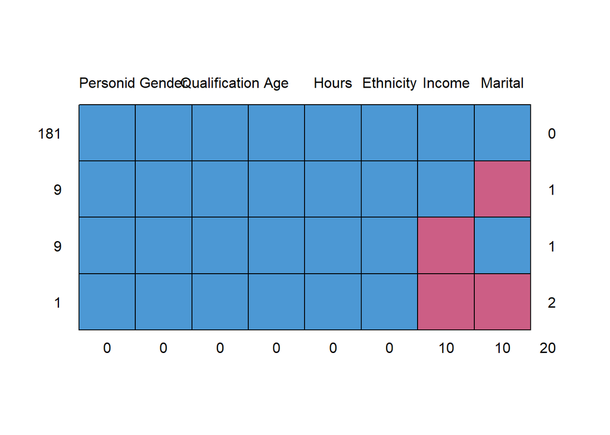

```
##     Personid Gender Qualification Age Hours Ethnicity Income Marital
## 181        1      1             1   1     1         1      1       1  0
## 9          1      1             1   1     1         1      1       0  1
## 9          1      1             1   1     1         1      0       1  1
## 1          1      1             1   1     1         1      0       0  2
##            0      0             0   0     0         0     10      10 20
```

```r
md.pattern(msurf)
```

An example dataset supplied with the `mice` package is `nhanes`, and is a tiny extract of 25 rows from the US National Health and Nutrition Examination Survey (NHANES). Note all variables are stored as numeric, though the `age` and `hyp` column are actually categorical.

We’ll create a copy of the dataset, call it `mnhanes` and recode the factor levels.

```r
mnhanes <- mice::nhanes
mnhanes$age <- factor(mnhanes$age)
mnhanes$hyp <- factor(mnhanes$hyp)
levels(mnhanes$age) <- c("20-39","40-59","60+")
levels(mnhanes$hyp) <- c("No","Yes")
mnhanes <- data.frame(id=factor(1:nrow(mnhanes)),mnhanes)
```

Here are the first 10 rows of the data, which include a lot of missing data for the variables `bmi` (body mass index, kg/m$^2$), `hyp` (presence of hypertension, 1=no, 2=yes) and `chl` (total serum cholesterol level, mg/dL).

| id | age | bmi | hyp | chl |
| --- | --- | --- | --- | --- |
| 1 | 20-39 | NA | NA | NA |
| 2 | 40-59 | 22.7 | No | 187 |
| 3 | 20-39 | NA | No | 187 |
| 4 | 60+ | NA | NA | NA |
| 5 | 20-39 | 20.4 | No | 113 |
| 6 | 60+ | NA | NA | 184 |
| 7 | 20-39 | 22.5 | No | 118 |
| 8 | 20-39 | 30.1 | No | 187 |
| 9 | 40-59 | 22.0 | No | 238 |
| 10 | 40-59 | NA | NA | NA |

Item non-response is indicated by an `NA` value. Notice that units 1, 4 and 10 provided no data at all, apart from their ages.

Here’s the missingness pattern in the NHANES dataset.

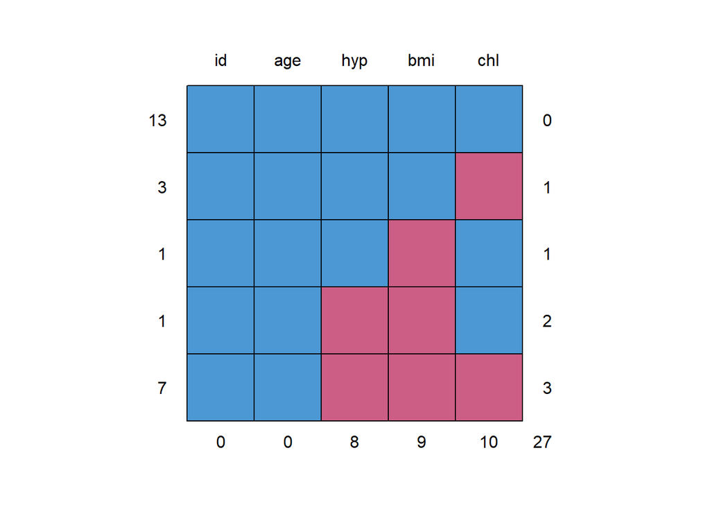

```
##    id age hyp bmi chl
## 13  1   1   1   1   1  0
## 3   1   1   1   1   0  1
## 1   1   1   1   0   1  1
## 1   1   1   0   0   1  2
## 7   1   1   0   0   0  3
##     0   0   8   9  10 27
```

```r
md.pattern(mnhanes)
```

## 9.1 Mean, median or mode imputation

The simplest method of imputing a variable is just to replace any missing value with a **typical** value from the units that did provide a response.

For numerical variables that can mean replacing missing values with the mean or the median. (We prefer the median of course if there are outliers.) For categorical variables the mode is the only **typical** value we have.

Let’s replace the missing values of `bmi` in the NHANES `mnhanes` dataset with the mean of the responding values:

```r
mnhanes1 <- mnhanes
mnhanes1$bmi.imp <- is.na(mnhanes1$bmi)
mnhanes1$bmi[is.na(mnhanes1$bmi)] <- mean(mnhanes1$bmi, na.rm=TRUE)
```

The code above does two things: in a new copy of the data set `mnhanes1` it creates a new column `bmi.imp` which is `TRUE` if the `bmi` value is missing.  
It then replaces `NA` values in the `bmi` column with the mean value 26.5625.

Here are the top 10 rows of the dataset after imputation.

| id | age | bmi | hyp | chl | bmi.imp |
| --- | --- | --- | --- | --- | --- |
| 1 | 20-39 | 26.5625 | NA | NA | TRUE |
| 2 | 40-59 | 22.7000 | No | 187 | FALSE |
| 3 | 20-39 | 26.5625 | No | 187 | TRUE |
| 4 | 60+ | 26.5625 | NA | NA | TRUE |
| 5 | 20-39 | 20.4000 | No | 113 | FALSE |
| 6 | 60+ | 26.5625 | NA | 184 | TRUE |
| 7 | 20-39 | 22.5000 | No | 118 | FALSE |
| 8 | 20-39 | 30.1000 | No | 187 | FALSE |
| 9 | 40-59 | 22.0000 | No | 238 | FALSE |
| 10 | 40-59 | 26.5625 | NA | NA | TRUE |

The function `impute()` does the same thing: we just specify the variable name and the method (mean, median or mode).

```r
mhnanes1 <- impute(mnhanes, varname="bmi", method="mean")
```

We can impute the categorical `hyp` variable using mode imputation and the numerical `chl` variable using median imputation

```r
mnhanes1 <- mnhanes1 |>
  impute(varname="hyp", method="mode") |>
  impute(varname="chl", method="median")
```

This leads to the fully imputed dataset (showing the first 10 rows only):

| id | age | bmi | hyp | chl | bmi.imp | hyp.imp | chl.imp |
| --- | --- | --- | --- | --- | --- | --- | --- |
| 1 | 20-39 | 26.5625 | No | 187 | TRUE | TRUE | TRUE |
| 2 | 40-59 | 22.7000 | No | 187 | FALSE | FALSE | FALSE |
| 3 | 20-39 | 26.5625 | No | 187 | TRUE | FALSE | FALSE |
| 4 | 60+ | 26.5625 | No | 187 | TRUE | TRUE | TRUE |
| 5 | 20-39 | 20.4000 | No | 113 | FALSE | FALSE | FALSE |
| 6 | 60+ | 26.5625 | No | 184 | TRUE | TRUE | FALSE |
| 7 | 20-39 | 22.5000 | No | 118 | FALSE | FALSE | FALSE |
| 8 | 20-39 | 30.1000 | No | 187 | FALSE | FALSE | FALSE |
| 9 | 40-59 | 22.0000 | No | 238 | FALSE | FALSE | FALSE |
| 10 | 40-59 | 26.5625 | No | 187 | TRUE | TRUE | TRUE |

There’s an obvious risk here: by filling in the most common or most typical value in the dataset we are **reducing variability** among the respondents and making the sample dominated by these typical values.

For example in Figure 9.1 the proportion of people with hypertension reduces from 4/17=24% to 4/25=16% because all of the missing individuals are assigned to the typical reponse of ‘no hypertension’.

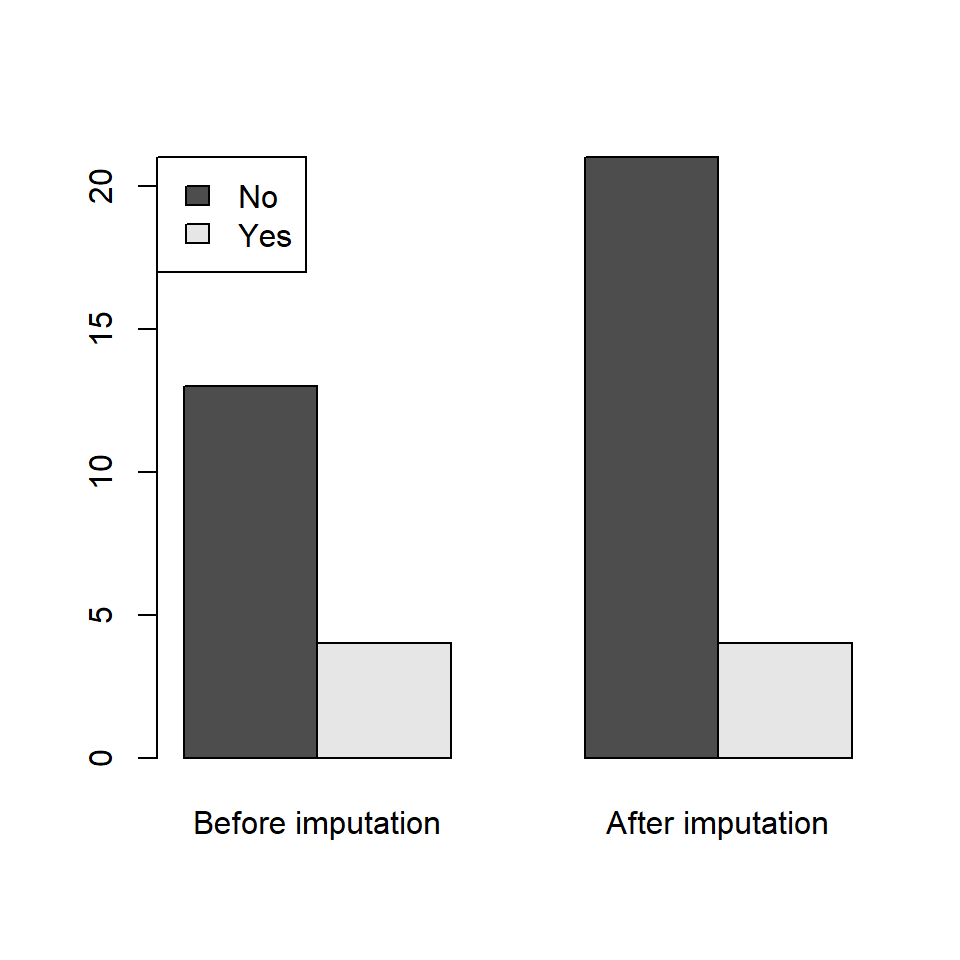

Likewise the distribution of BMI after mean imputation is far from realistic with a large artificial peak at the mean (Figure 9.2).

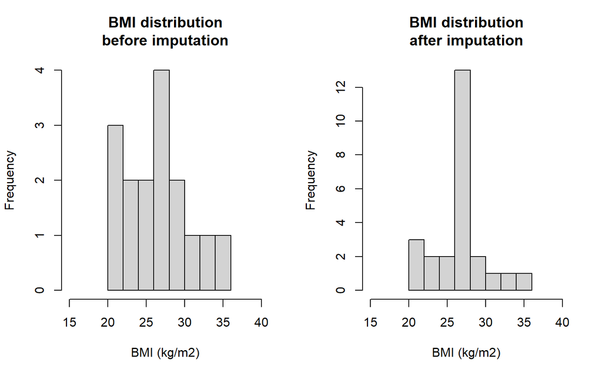

Figure 9.2: BMI distributions before and after mean imputation

If we are only imputing a small proportion of values this shouldn’t matter, but we’d prefer to have an imputation method that didn’t introduce such artefacts into the data.

## 9.2 Hot deck imputation

An attractive alternative to replacing an observation with the mean, median or mode is to choose another respondent at random, and copy over their data. These respondents are referred to as ‘donors’, who ‘donate’ a copy of their data to the respondent with missing data.

The `impute()` function does this, by specifying the method “sample”:

```r
set.seed(222)
mnhanes2 <- mnhanes |>
  impute(varname="bmi", method="sample") |>
  impute(varname="hyp", method="sample") |>
  impute(varname="chl", method="sample")
```

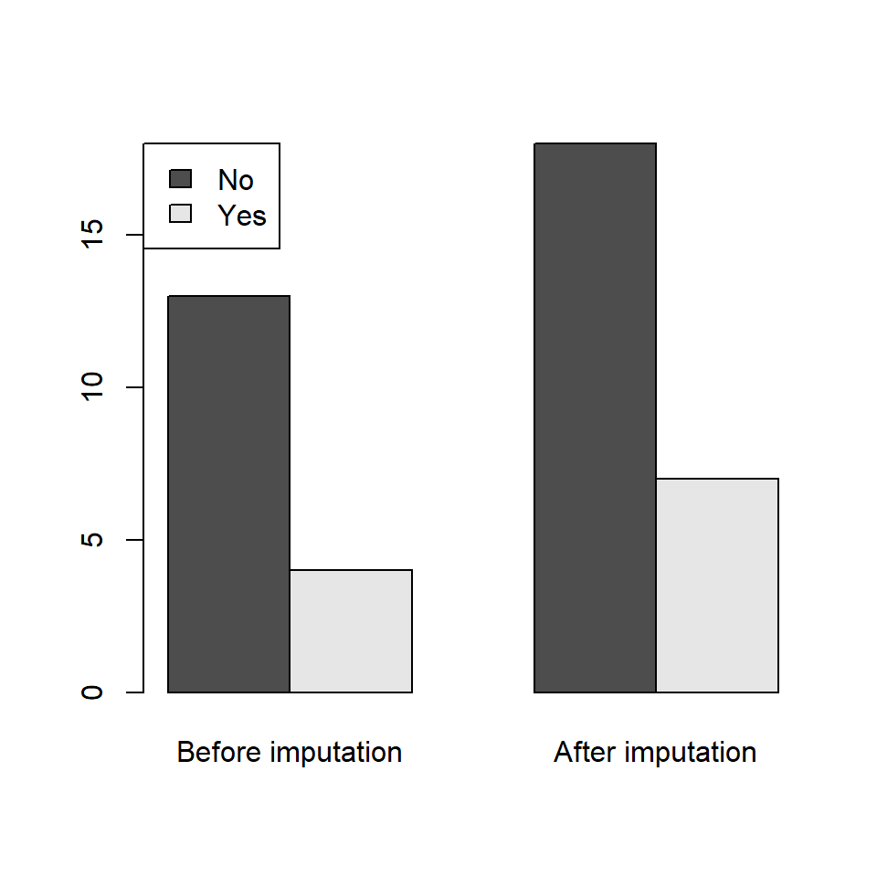

Figure 9.3: Distribution of the Hypertension variable before and after Hot Deck imputation

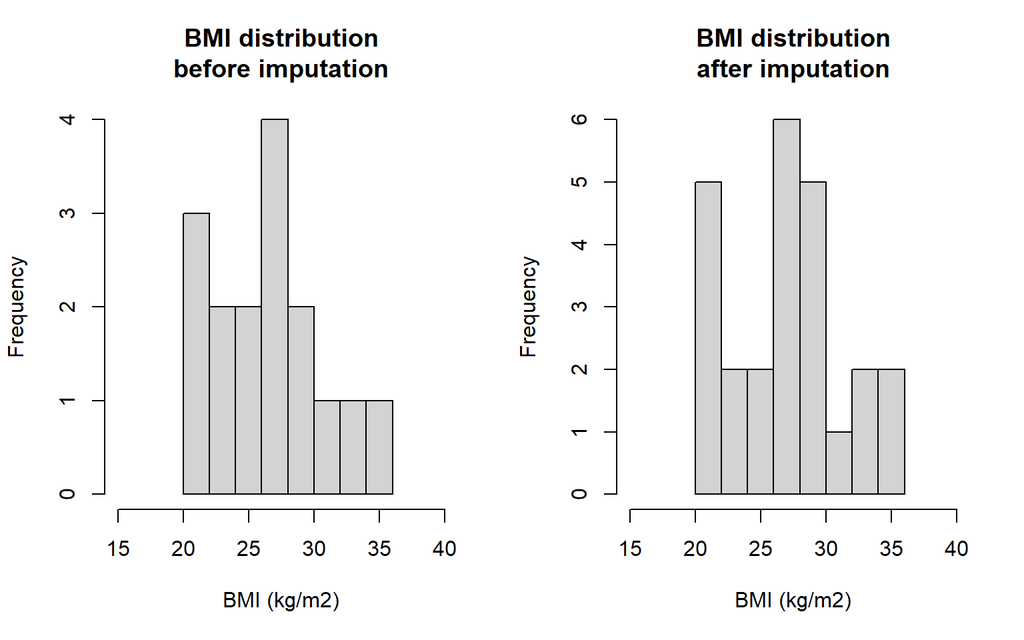

Figure 9.4: BMI distributions before and after Hot Deck imputation

The Hot Deck method gets its name from the ‘deck’ (like a deck of cards) of respondents with complete information from which we draw at random. ‘Hot’ refers to the fact that we are using respondents from the same survey as the donors. ‘Cold’ deck imputation uses data from another external data source as a source of donors.

**Important note** - you’ll get a different set of imputed values every time you do a hot deck imputation - so two analysts imputing data on the same data set will end up with different imputed values and therefore (slightly) different final estimates. If imputation is **minimal** then this shouldn’t be a problem.

## 9.3 Cell methods

We can do better still. We know that characteristics such as BMI, hypertension and cholesterol correlate strongly with age, and we know the age of everyone.

It makes sense to do mean, median, mode **and** hot deck imputation within **imputation cells**. These cells are groups of respondents who have the same characteristics: specified by a (set of) categorical variables. We have to know which imputation cell the respondent with missing data belongs to, so we must have complete data for the variables defining the imputation cells.

Once we have imputation cells defined we can do mean, median, mode or hot deck imputation within the cells.

In the `impute()` function we define the cells with the right hand side of a model formula which should only include categorical variables. If the formula includes numerical variables then it is unlikely that there will be anyone in the same cell as the respondent who needs a donor. So with a variable like age we use age groups to define the cells, rather than year of age.

Let’s do cell mean imputation for BMI, cell hot deck for hypertension, and cell median for cholesterol, all with cells defined by age group.

```r
set.seed(333)
mnhanes3 <- mnhanes |>
  impute(varname="bmi", method="mean", formula=~age) |>
  impute(varname="hyp", method="sample", formula=~age) |>
  impute(varname="chl", method="median", formula=~age)
```

We can compare BMI values by age group in our original and three imputed datasets

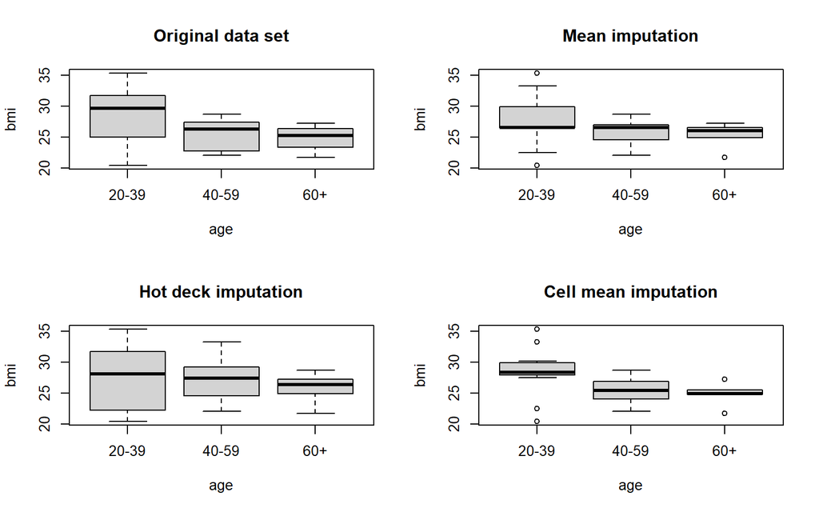

Figure 9.5: BMI distribution by age group after various imputation methods

## 9.4 Regression methods

A further extension of imputation methods leads us to **regression imputation**: using the complete data respondents we fit a regression model for our variable of interest, and then use it to predict the missing values. This works for numerical as well as categorical predictors, and includes cell mean imputation as a special case. As with the cell methods we need the respondents who need their values imputed to have complete data on the predictor variables.

Let’s switch to imputing the 10 missing weekly incomes in the SURF dataset `msurf`.

We first note that income depends clearly both on Gender and weekly hours worked:

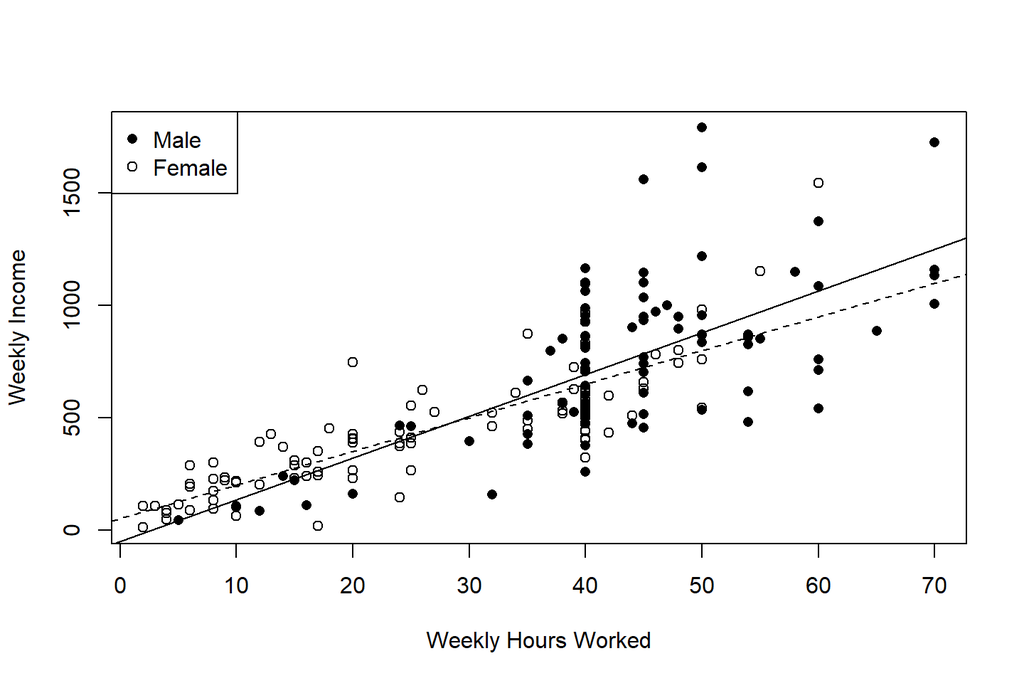

Figure 9.6: Weekly Income and Weekly Hours worked by Gender. The solid line shows the relationship for Males and the dashed line for Females

```r
msurf1 <- msurf |>
  impute(varname="Income", method="mean")
msurf2 <- msurf |>
  impute(varname="Income", method="lm.mean", formula=~Hours+Gender)
msurf3 <- msurf |>
  impute(varname="Income", method="lm.sim", formula=~Hours+Gender)
```

The results of the three imputation methods are shown in Figure 9.7.

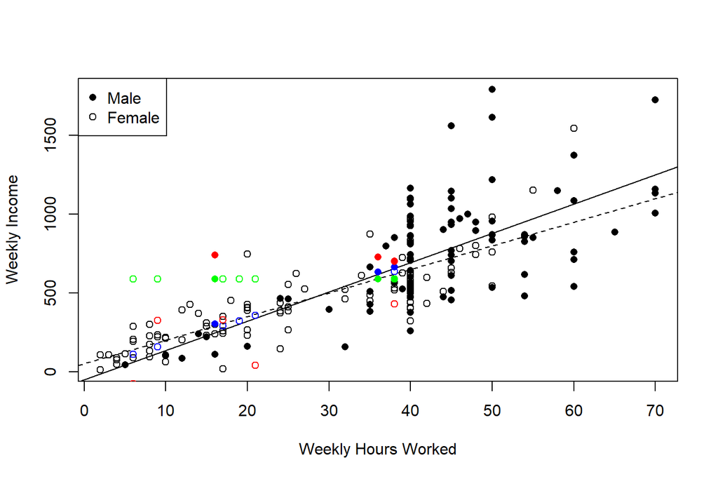

The first regression imputation has method `lm.mean` fits the model in equation (9.1), and then predicts directly onto the fitted regression line:
$$\text{ImputedIncome}_i = \widehat{\beta}_0 + \widehat{\beta}_1 \text{(Hours$_i$)}
+ \widehat{\beta}_2 I(\text{Gender$_i$=Female})$$
using the fitted regression parameters $(\widehat{\beta}_0, \widehat{\beta}_1, \widehat{\beta}_2)$. These imputed values are shown in blue, and are exactly where we’d expect a person of the given Gender and Hours worked to be earning.

This is very good, but in the spirit of hot deck imputation we can do even better: we know that observations should scatter around the the regression line, rather than lying directly on it. So the second regression method draws from the error distribution
$$\widehat{\varepsilon}_i \sim N(0,\widehat{\sigma}^2)$$
using the fitted standard deviation $(\widehat{\sigma})$. So the imputed value is the expected value plus this additional error, which bumps the prediction off the regression line:
$$\text{ImputedIncome}_i = \widehat{\beta}_0 + \widehat{\beta}_1 \text{(Hours$_i$)}
+ \widehat{\beta}_2 I(\text{Gender$_i$=Female})
+ \widehat{\varepsilon}_i$$
These imputed values are shown in red in Figure 9.7, and they look just like real data. To get these imputed values we change the method from “lm.mean” to “lm.sim” to change from the mean (expected) income, to a simulated value.

## 9.5 Multiple imputation

Instead of imputing a **single** value for each missing observation, we impute several possible imputed values - we end up with multiple completed data sets, in something of the same spirit as the replicate weights we get with the Jackknife.. The variability among estimates from these separate completed data sets gives us additional insight into the effect of our imputations, and the uncertainty we have associated with having missing data.

The confidence we can have regarding the true scale of the uncertainty depends on how strongly we believe in the model we’ve used to impute.

The `mice` package implements multiple imputation, that’s its major function.  
It’s more detail then we need for this course, but you should be aware that you’ll see multiple imputation methods from time to time.

# 10 Designing Surveys

The design of surveys is a massive topic, and we can’t cover much here. The key principle is that everything that is done in the design of a survey should be done to meet the Objectives (the research goals) of the survey. Nothing else matters.

For our purposes calculation of the sample size required when designing a survey is the most significant single decision to make since it determines the standard errors for the survey estimates. In real life the decision about sample size is often severely constrained by available resources.

## 10.1 Another interpretation of the Deff

Assume that for sample size $n$ the variance of an estimator in a specific design has the approximate formula
$$\bfa{Var}{\widehat{T}_\text{design}} = \frac{c_\text{design}}{n}$$
then using the definition of the Deff, the ratio of the variance with respect to SRSWOR, then
$$\begin{eqnarray}
\bfa{Deff}{\widehat{T}_{\text{design}}}
&=& \frac{\bfa{Var}{\widehat{T}_{\text{design}}}}{\bfa{Var}{\widehat{T}_{\text{SRSWOR}}}}\\
&=& \frac{c_\text{design}/n}{c_\text{SRSWOR}/n}\\
&=& \frac{c_\text{design}}{c_\text{SRSWOR}}
\end{eqnarray}$$
So if we want to find the sample sizes at which the variances in the design of interest and SRSWOR are equal, then we set
$$\begin{eqnarray}
V_\text{design} &=& V_\text{SRSWOR}\\
\frac{c_\text{design}}{n_\text{design}} &=& \frac{c_\text{SRSWOR}}{n_\text{SRSWOR}}\\
n_\text{design} &=& \frac{c_\text{design}}{c_\text{SRSWOR}}n_\text{SRSWOR}\\
&=& \bfa{Deff}{\widehat{T}_\text{design}} n_\text{SRSWOR}
\end{eqnarray}$$
This means that a rough way to compute the sample size required in a complex design is to first calculate the sample size we’d need in SRSWOR, and then scale it by the Deff for the complex design.

If the Deff is 2 (as it may be in a cluster design for example), then we need twice the sample size an SRSWOR would need in order to achieve the same standard error.

## 10.2 Computing the Required Sample Size

1. Identify your **design estimate** – this is the estimate that will underlie a headline you could imagine being written about your survey.
2. Identify the desired MOE, $m$, for this design estimate, noting whether you want this MOE to apply to the overall estimate, or for that estimate in each of, say, $H$ subgroups/strata.
3. Compute the sample size required, $n_1$, assuming that you’re going to select a Simple Random Sample and ignoring the fpc.

   For estimation of a mean $\bar{Y}$ of some characteristic $y$:
   $$n_1 = \left(\frac{Z}{MOE}\right)^2 s^2$$
   where $Z$ is appropriate for the desired level of confidence and $s$ is the estimated population standard deviation of the characteristic $y$.

   For estimation of a proportion $P$:
   $$n_1 = \left(\frac{Z}{MOE}\right)^2 p(1-p)$$
   where $p$ is the estimated proportion, or 0.5 if really unknown.
4. If the sample size is a substantial proportion of the population or subgroup size $N$, then apply the fpc adjustment:
   $$n_2 = \frac{n_1}{1+\frac{n_1}{N}}$$
   This adjusts for the fact that in a finite population we don’t need quite as large a sample to achieve the same standard error. However if the sampling fraction ($n/N$: the proportion of the population that is selected) is small, then the fpc adjustment has very little effect.
5. If you have $H$ subgroups and are using equal allocation then multiply by $H$
   $$n_3 = Hn_2$$
   or alternatively sum over the $n_2$ values in each of the strata you’ve defined.
6. Apply the design effect (Deff) appropriate for the actual design you’ll be using.
   $$n_4 = \text{Deff}\times n_3$$
7. Adjust for anticipated non-response: if response rate $\phi$ is expected then
   $$n_5 = \frac{n_4}{\phi}$$
   (If non-response is likely to vary between strata, then apply this correction to $n_2$, within each stratum.)

# References

Cochran, W. G. 1977. *Sampling Techniques*. Third. Wiley.

Kish, L. 1965. *Survey Sampling*. Wiley.

Little, R. J. A., and D. B. Rubin. 2002. *Statistical Analysis with Missing Data*. Second. Wiley.

Lohr, Sharon L. 1999. *Sampling: Design and Analysis*. Duxbury Press.

Lumley, Thomas. 2004. “Analysis of Complex Survey Samples.” *Journal of Statistical Software* 9 (1): 1–19.

Lumley, Thomas S. 2010. *Complex Surveys: A Guide to Analysis Using r (Wiley Series in Survey Methodology)*. Wiley.

Särndal, C-E., B. Swensson, and J. Wretmann. 1992. *Model Assisted Survey Sampling*. Springer-Verlag.

Scheaffer, R. L., W. Mendenhall III, and R. L. Ott. 2006. *Elementary Survey Sampling*. Sixth. Duxbury.

Zealand, Statistics New. 1995. *A Guide to Good Survey Design*. Second. Statistics New Zealand.